# D213 - Advanced Data Analytics

Sentiment Analysis using Neural Networks

Sean P. Murphy

21 June 2022

# Introduction

Prior to beginning the assigned sentiment analysis, we will provide some sense of the how this assignment fits into the overall context of our coursework so far and also prepare the environment for this project.

## Assignment Background

In our previous coursework, we were tasked by a popular hospital chain with analyzing several datasets, each with a slightly different focus. Initially, we identified criteria to quantify risk levels for patient readmission within one month of their initial discharge. When provided with patient prescription histories, we uncovered patterns that revealed the potential for medication interaction risks. Using patient survey data, we uncovered the existence of two specific groups of patients with distinct and diverging priorities so that the hospital can tailor individual marketing and patient care strategies more appropriately. Lastly, we provided daily revenue benchmarks against which policymakers can compare hospital revenue after implementing changes in policy or strategy to assess their relative success.

## Initial Preparation

```r
# Visualization Formatting
library(gridExtra)
library(viridis)

# Visualization Font Import
library(sysfonts)
library(showtextdb)
library(showtext)
font_add("LM Roman 10", "./lmroman10-regular.otf")
```

We will be loading a number of required libraries to perform some simple data manipulation (*dplyr* and *purr*), create visualizations (*ggplot2*), and to perform the bulk of the sentiment analysis analysis (*keras*).

```r
library(keras)
library(dplyr)
library(ggplot2)
library(purrr)
library(tidytext)
library(SnowballC)
```

# Part I: Research Scope

## A1: Research Question

> Describe the purpose of this data analysis by doing the following:: Summarize one research question that you will answer using neural network models and NLP techniques. Be sure the research question is relevant to a real-world organizational situation and sentiment analysis captured in your chosen dataset.

## A2: Research Objective

> Describe the purpose of this data analysis by doing the following:: Define the objectives or goals of the data analysis. Be sure the objectives or goals are reasonable within the scope of the research question and are represented in the available data.

## A3: Research Mechanism

> Describe the purpose of this data analysis by doing the following:: Identify a type of neural network capable of performing a text classification task that can be trained to produce useful predictions on text sequences on the selected data set.

# Part II: Data Preparation

We will now import our selected data set prior to performing some exploratory data analysis and data preparation.

```r
df <- readr::read_csv('./imdb_labelled.csv', col_names = FALSE)
colnames(df) <- c('Review', 'Sentiment')
df$Sentiment <- as.factor(df$Sentiment)
summary(df)
```

```
    Review          Sentiment
 Length:1000        0:500
 Class :character   1:500
 Mode  :character
```

## B1: Exploratory Data Analysis

> Summarize the data cleaning process by doing the following: Perform exploratory data analysis on the chosen dataset, and include an explanation of each of the following elements:

```r
head(df)
```

| Review | Sentiment |
| --- | --- |
| A very, very, very slow-moving, aimless movie about a distressed, drifting young man. | 0 |
| Not sure who was more lost - the flat characters or the audience, nearly half of whom walked out. | 0 |
| Attempting artiness with black & white and clever camera angles, the movie disappointed - became even more ridiculous - as the acting was poor and the plot and lines almost non-existent. | 0 |
| Very little music or anything to speak of. | 0 |
| The best scene in the movie was when Gerardo is trying to find a song that keeps running through his head. | 1 |
| The rest of the movie lacks art, charm, meaning... If it's about emptiness, it works I guess because it's empty. | 0 |

### Vocabulary Size

A very common problem with sentiment analysis using a body of text is that many of the words that we use with significant frequency do not convey any information about the feelings of the speaker.

### Proposed Word Embedding Length

### Statistical Justification for the chosen maximum sequence length

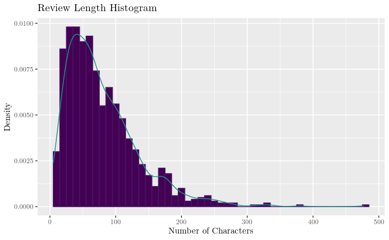

## B2: Tokenization

> Summarize the data cleaning process by doing the following: Describe the goals of the tokenization process, including any code generated and packages that are used to normalize text during the tokenization process.

tidytext

We will be reducing the text array in the review content column to individual words.

```r
df.clean <- df %>%
  unnest_tokens(word, Review)
```

With the individual words separated, we will examine the most frequently used words in the text of the IMDb movie reviews. We notice that the top twenty words in the body IMDb review texts do not convey the speakers feelings about the movie.

```r
df.clean %>%
  count(word, sort=TRUE) %>%
  head(20)
```

| word | n |
| --- | --- |
| the | 848 |
| and | 434 |
| a | 433 |
| of | 377 |
| is | 340 |
| this | 292 |
| i | 268 |
| it | 255 |
| to | 253 |
| in | 203 |

[output cut: 10 more lines]

We will remove these common stop words from the review content before proceeding. This will help enforce the principle of least effort and remove words that do not help identify the sentiment of a body of text.

```r
df.clean <- anti_join((unnest_tokens(df.clean, word, word)), stop_words)
df.clean %>% count(word, sort = TRUE)
```

| word | n |
| --- | --- |
| movie | 181 |
| film | 160 |
| bad | 71 |
| acting | 43 |
| time | 43 |
| characters | 35 |
| 10 | 29 |
| movies | 29 |
| plot | 28 |
| story | 28 |

[output cut: 990 more lines]

Based on our cursory observation above, we note that some of the more common words can also be removed due to their sentiment neutrality.

```r
custom <- add_row(stop_words, word="movie", lexicon="custom")
custom <- add_row(custom, word="movies", lexicon="custom")
custom <- add_row(custom, word="movie's", lexicon="custom")

df.clean <- anti_join(df.clean, custom)
df.clean %>% count(word, sort = TRUE)
```

| word | n |
| --- | --- |
| film | 160 |
| bad | 71 |
| acting | 43 |
| time | 43 |
| characters | 35 |
| 10 | 29 |
| plot | 28 |
| story | 28 |
| films | 24 |
| script | 24 |

[output cut: 990 more lines]

Lastly, for this section, we will apply a stemming function. This will render some words slightly less human-readable but it will consolidate words with similar meanings but varying forms such that their overall impact isn’t artificially weakened.

```r
df.clean <- mutate(df.clean, word = wordStem(word))

df.clean %>% count(word, sort = TRUE)
```

| word | n |
| --- | --- |
| film | 186 |
| bad | 71 |
| charact | 58 |
| time | 50 |
| act | 48 |
| watch | 48 |
| love | 37 |
| scene | 33 |
| stori | 32 |
| 10 | 29 |

[output cut: 990 more lines]

## B3: Padding

> Summarize the data cleaning process by doing the following: Explain the padding process used to standardize the length of sequences, including the following in your explanation:

In order to make the body of the review text more compatible with a neural network analysis, we could one-hot-encode the arrays based on the $n$ most common words, creating an $n$-dimensional vector. However, this would be considerably memory intensive; hence, we will choose to pad the arrays instead.

Rather than one-hot encoding our text to $n$-dimensional vectors, we will coerce each of the arrays into having the same length regardless of the number of characters in the review itself.

## B4: Sentiment Categories

```r
summary(df.clean$Sentiment)
```

```
   0    1
2419 2893
```

## B5: Train/Test Split

We will adhere to a fairly common 80/20 train/test split for the purposes of this project.

```r
set.seed(213)
split.index <- sample.int(nrow(df.clean), size = nrow(df)*0.8)
df.train <- df.clean[split.index,]
df.test <- df.clean[-split.index,]
```

## B6: Data Export

```r
write.csv(df.train, './nn_testing.csv', row.names = FALSE)
write.csv(df.test, './nn_training.csv', row.names = FALSE)
```

# Part III: Network Architecture

## C1: Model Summary

> Describe the type of network used by doing the following: Provide the output of the model summary of the function from TensorFlow.

## C2: Layers and Parameters

> Describe the type of network used by doing the following: Discuss the number of layers, the type of layers, and total number of parameters.

### Text Vectorization Layer

We define our text vectorization later here. It will take our string input and convert that data to a tensor.

```r
num_words <- 10000
max_length <- 10
text_vectorization <- layer_text_vectorization(
  max_tokens = num_words,
  output_sequence_length = max_length,
)
```

```r
text_vectorization %>%
  adapt(df.clean$word)
head(get_vocabulary(text_vectorization))
```

```
[1] ""        "[UNK]"   "film"    "bad"     "charact" "time"
```

```r
text_vectorization(matrix(df.clean$word[1], ncol = 1))
```

```
tf.Tensor([[127   0   0   0   0   0   0   0   0   0]], shape=(1, 10), dtype=int64)
```

## C3: Hyperparameters

> Describe the type of network used by doing the following: Justify the choice of hyperparameters, including the following elements:

```r
input <- layer_input(shape = c(1), dtype = "string")

output <- input %>%
  text_vectorization() %>%
  layer_embedding(input_dim = num_words + 1, output_dim = 16) %>%
  layer_global_average_pooling_1d() %>%
  layer_dense(units = 16, activation = "relu") %>%
  layer_dropout(0.5) %>%
  layer_dense(units = 1, activation = "sigmoid")

model <- keras_model(input, output)
```

### Loss Function

```r
model %>% compile(loss = 'binary_crossentropy')
```

### Optimizer

```r
model %>% compile(optimizer = 'adam')
```

### Number of Nodes per Layer

### EvaluationMetric

Accuracy

```r
model %>% compile(
  optimizer = 'adam',
  loss = 'binary_crossentropy',
  metrics = list('accuracy')
)
```

# Part IV: Model Evaluation

With the network layers and parameters discussed above, we will not train and evaluate the model.

```r
history <- model %>% fit(
            df.train$word,
            as.numeric(df.train$Sentiment == 1),
            epochs = 20,
            batch_size = 100,
            validation_split = 0.1,
            verbose=2)
```

```
8/8 - 1s - loss: 0.6926 - accuracy: 0.5153 - val_loss: 0.6959 - val_accuracy: 0.4375 - 1s/epoch - 132ms/step
8/8 - 0s - loss: 0.6900 - accuracy: 0.5500 - val_loss: 0.6980 - val_accuracy: 0.4375 - 145ms/epoch - 18ms/step
8/8 - 0s - loss: 0.6894 - accuracy: 0.5472 - val_loss: 0.7003 - val_accuracy: 0.4375 - 142ms/epoch - 18ms/step
8/8 - 0s - loss: 0.6913 - accuracy: 0.5472 - val_loss: 0.7020 - val_accuracy: 0.4375 - 146ms/epoch - 18ms/step
8/8 - 0s - loss: 0.6894 - accuracy: 0.5472 - val_loss: 0.7023 - val_accuracy: 0.4375 - 144ms/epoch - 18ms/step
8/8 - 0s - loss: 0.6878 - accuracy: 0.5472 - val_loss: 0.7039 - val_accuracy: 0.4375 - 146ms/epoch - 18ms/step
8/8 - 0s - loss: 0.6888 - accuracy: 0.5472 - val_loss: 0.7045 - val_accuracy: 0.4375 - 141ms/epoch - 18ms/step
8/8 - 0s - loss: 0.6872 - accuracy: 0.5472 - val_loss: 0.7049 - val_accuracy: 0.4375 - 140ms/epoch - 18ms/step
8/8 - 0s - loss: 0.6870 - accuracy: 0.5472 - val_loss: 0.7054 - val_accuracy: 0.4375 - 145ms/epoch - 18ms/step
8/8 - 0s - loss: 0.6870 - accuracy: 0.5472 - val_loss: 0.7054 - val_accuracy: 0.4375 - 141ms/epoch - 18ms/step
8/8 - 0s - loss: 0.6857 - accuracy: 0.5472 - val_loss: 0.7051 - val_accuracy: 0.4375 - 144ms/epoch - 18ms/step
8/8 - 0s - loss: 0.6852 - accuracy: 0.5472 - val_loss: 0.7046 - val_accuracy: 0.4375 - 145ms/epoch - 18ms/step
8/8 - 0s - loss: 0.6839 - accuracy: 0.5472 - val_loss: 0.7041 - val_accuracy: 0.4375 - 145ms/epoch - 18ms/step
8/8 - 0s - loss: 0.6839 - accuracy: 0.5472 - val_loss: 0.7047 - val_accuracy: 0.4375 - 142ms/epoch - 18ms/step
8/8 - 0s - loss: 0.6813 - accuracy: 0.5472 - val_loss: 0.7050 - val_accuracy: 0.4375 - 143ms/epoch - 18ms/step
8/8 - 0s - loss: 0.6812 - accuracy: 0.5472 - val_loss: 0.7044 - val_accuracy: 0.4375 - 143ms/epoch - 18ms/step
8/8 - 0s - loss: 0.6789 - accuracy: 0.5486 - val_loss: 0.7031 - val_accuracy: 0.4375 - 143ms/epoch - 18ms/step
8/8 - 0s - loss: 0.6784 - accuracy: 0.5569 - val_loss: 0.7028 - val_accuracy: 0.4375 - 142ms/epoch - 18ms/step
8/8 - 0s - loss: 0.6780 - accuracy: 0.5542 - val_loss: 0.7017 - val_accuracy: 0.4375 - 142ms/epoch - 18ms/step
8/8 - 0s - loss: 0.6741 - accuracy: 0.5611 - val_loss: 0.7022 - val_accuracy: 0.4375 - 142ms/epoch - 18ms/step
```

## D1: Final Epoch

> Evaluate the model training process and its relevant outcomes by doing the following: Discuss the impact of using stopping criteria instead of defining the number of epochs, including a screenshot showing the final training epoch.

## D2: Loss and Accuracy

> Evaluate the model training process and its relevant outcomes by doing the following: Provide visualizations of the model’s training process, including a line graph of the loss and chosen evaluation metric.

```r
results <- model %>% evaluate(df.test$word, as.numeric(df.test$Sentiment == 1), verbose = 0)
results
```

```
     loss  accuracy
0.6867229 0.5460993
```

## D3: Model Fitness

> Evaluate the model training process and its relevant outcomes by doing the following: Assess the fitness of the model and any measures taken to address overfitting.

## D4: Predictive Accuracy

> Evaluate the model training process and its relevant outcomes by doing the following: Discuss the predictive accuracy of the trained network.

[figure not shown]

```r
plot(history)
```

# Part V: Summary and Recommendations

## E: Code Copy

```r
df$Review %>%
  strsplit(" ") %>%
  sapply(length) %>%
  summary()
```

```
   Min. 1st Qu.  Median    Mean 3rd Qu.    Max.
   1.00    7.00   12.00   14.35   19.00   71.00
```

```r
set.seed(213)
split.index <- sample.int(nrow(df), size = nrow(df)*0.8)
training <- df[split.index,]
testing <- df[-split.index,]

num_words <- 10000
max_length <- 50
text_vectorization <- layer_text_vectorization(
  max_tokens = num_words,
  output_sequence_length = max_length,
)


text_vectorization %>%
  adapt(df$Review)

head(get_vocabulary(text_vectorization))
```

```
[1] ""      "[UNK]" "the"   "a"     "and"   "of"
```

```r
text_vectorization(matrix(df$Review[1], ncol = 1))
```

```
tf.Tensor(
[[   3   27   27   27 1599 3109   13   36    3 2666 2645  395  148    0
     0    0    0    0    0    0    0    0    0    0    0    0    0    0
     0    0    0    0    0    0    0    0    0    0    0    0    0    0
     0    0    0    0    0    0    0    0]], shape=(1, 50), dtype=int64)
```

```r
input <- layer_input(shape = c(1), dtype = "string")

output <- input %>%
  text_vectorization() %>%
  layer_embedding(input_dim = num_words + 1, output_dim = 16) %>%
  layer_global_average_pooling_1d() %>%
  layer_dense(units = 16, activation = "relu") %>%
  layer_dropout(0.5) %>%
  layer_dense(units = 1, activation = "sigmoid")

model <- keras_model(input, output)


model %>% compile(
  optimizer = 'adam',
  loss = 'binary_crossentropy',
  metrics = list('accuracy')
)

history <- model %>% fit(
            training$Review,
            as.numeric(training$Sentiment == 1),
            epochs = 20,
            batch_size = 100,
            validation_split = 0.1,
            verbose=2)
```

```
8/8 - 1s - loss: 0.6932 - accuracy: 0.4903 - val_loss: 0.6926 - val_accuracy: 0.5125 - 1s/epoch - 130ms/step
8/8 - 0s - loss: 0.6920 - accuracy: 0.5389 - val_loss: 0.6923 - val_accuracy: 0.5375 - 152ms/epoch - 19ms/step
8/8 - 0s - loss: 0.6918 - accuracy: 0.5472 - val_loss: 0.6920 - val_accuracy: 0.5000 - 152ms/epoch - 19ms/step
8/8 - 0s - loss: 0.6913 - accuracy: 0.5514 - val_loss: 0.6918 - val_accuracy: 0.5000 - 149ms/epoch - 19ms/step
8/8 - 0s - loss: 0.6905 - accuracy: 0.5694 - val_loss: 0.6912 - val_accuracy: 0.5000 - 152ms/epoch - 19ms/step
8/8 - 0s - loss: 0.6901 - accuracy: 0.5472 - val_loss: 0.6908 - val_accuracy: 0.5000 - 152ms/epoch - 19ms/step
8/8 - 0s - loss: 0.6892 - accuracy: 0.5972 - val_loss: 0.6901 - val_accuracy: 0.5250 - 148ms/epoch - 19ms/step
8/8 - 0s - loss: 0.6883 - accuracy: 0.6139 - val_loss: 0.6893 - val_accuracy: 0.7750 - 148ms/epoch - 18ms/step
8/8 - 0s - loss: 0.6879 - accuracy: 0.6139 - val_loss: 0.6884 - val_accuracy: 0.7125 - 147ms/epoch - 18ms/step
8/8 - 0s - loss: 0.6854 - accuracy: 0.6542 - val_loss: 0.6876 - val_accuracy: 0.7750 - 152ms/epoch - 19ms/step
8/8 - 0s - loss: 0.6849 - accuracy: 0.6806 - val_loss: 0.6864 - val_accuracy: 0.7375 - 148ms/epoch - 19ms/step
8/8 - 0s - loss: 0.6830 - accuracy: 0.7000 - val_loss: 0.6852 - val_accuracy: 0.7375 - 147ms/epoch - 18ms/step
8/8 - 0s - loss: 0.6796 - accuracy: 0.7056 - val_loss: 0.6838 - val_accuracy: 0.7625 - 150ms/epoch - 19ms/step
8/8 - 0s - loss: 0.6781 - accuracy: 0.7250 - val_loss: 0.6823 - val_accuracy: 0.7750 - 147ms/epoch - 18ms/step
8/8 - 0s - loss: 0.6752 - accuracy: 0.7292 - val_loss: 0.6802 - val_accuracy: 0.7875 - 146ms/epoch - 18ms/step
8/8 - 0s - loss: 0.6708 - accuracy: 0.7736 - val_loss: 0.6777 - val_accuracy: 0.7375 - 149ms/epoch - 19ms/step
8/8 - 0s - loss: 0.6694 - accuracy: 0.7528 - val_loss: 0.6749 - val_accuracy: 0.7000 - 147ms/epoch - 18ms/step
8/8 - 0s - loss: 0.6643 - accuracy: 0.7389 - val_loss: 0.6720 - val_accuracy: 0.7750 - 151ms/epoch - 19ms/step
8/8 - 0s - loss: 0.6566 - accuracy: 0.7958 - val_loss: 0.6688 - val_accuracy: 0.8125 - 152ms/epoch - 19ms/step
8/8 - 0s - loss: 0.6528 - accuracy: 0.7958 - val_loss: 0.6647 - val_accuracy: 0.8250 - 147ms/epoch - 18ms/step
```

```r
results <- model %>% evaluate(testing$Review, as.numeric(testing$Sentiment == 1), verbose = 0)
results
```

```
     loss  accuracy
0.6756431 0.7150000
```

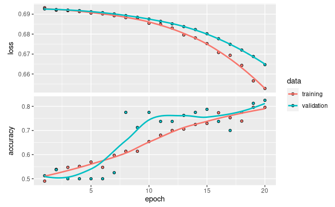

```r
plot(history)
```

## F: Code Functionality

> Discuss the functionality of your neural network, including the impact of the network architecture.

## G: Recommendations

> Recommend a course of action based on your results.

# Part VI: Reporting

## H: IDE Selection

The entirety of this submission was authored within an R Notebook using RStudio Server version 2022.02.2, build number 485 (RStudio Team, 2022). This instance was installed on a virtual instantiation of Ubuntu Server 20.04.4 LTS.

As we have done with all other submissions in this program, we will include a knitted pdf of this executed notebook.

## I-J: Academic Integrity

All sources for research and code usage have been cited in-text where appropriate, and a complete listing of these references is provided below.

## K: Communication Standards

Content has been edited for professionalism and appropriate communication standards.

# References

Kotzias, D., Denil, M., Freitas, N. & Smyth, P. 2015. From Group to Individual Labels Using Deep Features. In Proceedings of the 21th ACM SIGKDD International Conference on Knowledge Discovery and Data Mining (KDD ’15). Association for Computing Machinery, New York, NY, USA, 597–606. https://doi.org/10.1145/2783258.2783380

Maas, A., Daly, R., Pham, P., Huang, D., Ng, A. & Potts, C. (2011). Learning Word Vectors for Sentiment Analysis. 142-150. https://aclanthology.org/P11-1015

RStudio Team (2022). RStudio: Integrated Development Environment for R. RStudio, PBC, Boston, MA. http://www.rstudio.com/.